# Jian-Guo Zhou 周建国

jianguo.zhou@zmu.edu.cn  
github.com/JianGuoZhou3  
[ORCID](https://orcid.org/0000-0002-5021-3739) [Scholar](https://scholar.google.com/citations?user=1CLZex8AAAAJ&hl=zh-CN)

## Research summary

I am a Deputy Chief Physician (Doctoral Supervisor) of Zunyi Medical University. My research is dedicated to enhancing the efficacy of cancer immunotherapy and radiation/chemotherapy while minimizing adverse effects.

Together with Dr. Shixiang Wang, I lead the OncoHarmony Network[^1], a dynamic collaborative platform aimed at advancing the frontier of cancer immunotherapy. This network unites diverse teams from leading universities and research institutions, focusing on the exploration, mining, and integration of multi-omics data in cancer research. By fostering synergy among experts, the OncoHarmony Network seeks to create a comprehensive resource hub and cutting-edge tools to unravel the complexities of tumor-immune interactions, accelerating breakthroughs in cancer therapy development.

## Research positions

| year | what |
| --- | --- |
| 2017 | Primary Investigator, Department of Oncology, Second Affiliated hospital of Zunyi Medical University[^2] |

## Medical positions

| year | what |
| --- | --- |
| 2024 | Deputy Chief Physician, Doctoral Supervisor, Oncology, Second Affiliated hospital of Zunyi Medical University[^3] |
| 2019 | Attending Physician, Master Thesis Supervisor, Oncology, Second Affiliated hospital of Zunyi Medical University[^4] |
| 2017 | Residency, Oncology, Second Affiliated hospital of Zunyi Medical University[^5] |

## Education

| year | what |
| --- | --- |
| 2019 | Dr. rer. biol. hum (PhD) in Radiation Oncology [summa cum laude], Friedrich-Alexander-Universität Erlangen-Nürnberg[^6] Supervisor: Prof. Udo Gaipl[^7] |
| 2014 | M.S. in Thoracic Oncology, Zunyi Medical University[^8] Supervisor: Prof. Hu Ma[^9] |
| 2009 | M.D. in Clinical Medicine, Northwest Minzu University Supervisor: Prof. Siwu Fu |

## Committee Memberships

| year | what |
| --- | --- |
| 2025 | Member, Committee of Neoplastic Supportive-care (CONS), Chinese Anti-Cancer Association (CACA) |
| 2025 | Member, Expert Committee of Melanoma, Chinese Society of Clinical Oncology (CSCO) |
| 2024 | Member, Youth Expert Committee, West China Society of Therapeutic and Radiation Oncology (CSWOG-RTOG) |
| 2023 | Member, Committee of Thoracic Oncology Precision Treatment, China Primary Health Care Foundation (CPHCF) |
| 2023 | Member, Committee of Application of Foods for Special Medical Purposes, China Nutrition and Health Food Association (CNHFA) |

## Service

| year | what |
| --- | --- |
| 2025 | Editorial Board Member of BJC reports |
| 2023 | Editorial Board Member of BMC Medicine |
| 2023 | Associate Editor of European Journal of Medical Research |
| 2022 | Associate Editor of Frontiers in Immunology |
| 2022 | Associate Editor of Frontiers in Oncology |
| 2022 | Associate Editor Technology in Cancer Reasech & Treatment |
| 2018 | Journal Referees: Nature Medicine, Innovation, BMC Medicine, Seminars in Cancer Biology, cancer commnuications, Journal of Experimental & Clinical Cancer Research, Cell Proliferation, Frontiers in Imm… |
| 2018 | Section Editor of Cancer Control |
| 2022 | Guest Editor of Therapeutic Advances in Med Oncol: Genomic Biomarkers in Cancer Immunotherapy |

## Major grants and funding

| year | what |
| --- | --- |
| 2024 | Zunyi Medical University (ZYSE-2023-02)[^10] (¥ 2100k), Title: Future Science and Technology Elite Talent Cultivation Project |
| 2021 | Lian Yun Gang Shi Hui Lan Public Foundation (Grant No. HL-HS2020-92)[^11] (¥ 50k), Title: Based on machine learning methods to explore the role of multi-omics as predictor for NSCLC treated with third… |
| 2021 | National Natural Science Foundation of China[^12] (¥ 340k), Title: Long noncoding RNA MALAT1 promotes Invasion and Metastasis via the FGF23 / β-catenin pathway-mediated EMT in Uterine Sarcoma |
| 2019 | Research Programs of Health Commission Foundation of Guizhou Province, gzwjkj2019-1-073[^13] (¥ 20k), Title: Identification and validation of Immune related Prognostic Models in Oral Squamous Cell Car… |
| 2018 | the Special Key Laboratory of Oral Diseases Research, Higher Education Institution in Guizhou Province, No.05] (¥ 20k), Title: Identification and validation of a Prognostic Signature in Oral Cancer |

## Awards & honours

| year | what |
| --- | --- |
| 2024 | 2024 Guizhou Pharmaceutical Science and Techonology Award (Second Class, 1/6), Guizhou |
| 2022 | Chinese Government Award for Outstanding Self-financed Students Abroad (2021-A404), Germany |
|  | 2021 Guizhou Medical Science and Techonology Award (Second Class, 1/6), Guizhou |
| 2020 | KSMO 2020 Young Investigator Award, Seoul |
|  | 2018 Guizhou Medical Science and Techonology Award (Third Class, 4/5), Guizhou |
| 2019 | ESMO Asia 2019 Merit Award, Singapore |
|  | CSCO Young Oncologist Award (35 under 35), Beijing |
| 2018 | ESMO Asia 2018 Merit Award, Singapore |

## Publications

### Journal articles (fully reviewed, # for co-first, † for corresponding)

| year | number | citation |
| --- | --- | --- |
| 2024 | J64 | Single-cell RNA-seq reveals FGF12 as a prognostic biomarker in low-grade endometrial stromal sarcoma Y. Miao<sup>#</sup>, M. Dong<sup>#</sup>, Q. Zhou<sup>#</sup>, J. Thiel, N. Li, Y. Cai, D. Yuan, H.… |
|  | J63 | Efficacy of radiotherapy combined with atezolizumab or docetaxel in patients with previously treated NSCLC J. Xu<sup>#</sup>, H. Wang<sup>#</sup>, C. Zhang, S. Jin, X. Chen, F. Tan, B. Frey, M. Hecht,… |
|  | J62 | Facilitating integrative and personalized oncology omics analysis with UCSCXenaShiny S. Li<sup>#</sup>, Y. Peng, M. Chen, Y. Zhao, Y. Xiong, J. Li, P. Luo, H. Wang, F. Zhao, Q. Zhao, Y. Cui, S. Chen†,… |
|  | J61 | A Single-Arm Multi-Center Phase II Clinical Trial of Cadonilimab (anti-PD-1/CTLA-4) in Combination with or without Conventional Second-Line Treatment for Patients with Extensive Stage Small Cell Lung … |
|  | J60 | FGF23 is a potential prognostic biomarker in uterine sarcoma L. Yang<sup>#</sup>, Y. Cai<sup>#</sup>, Y. Wang, Y. Huang, C. Zhang, H. Ma†, J. Zhou† [Technology in Cancer Research and Treatment **(JCR … |
|  | J59 | Effects of serial radon spa therapy on pain and peripheral immune status in patients suffering from musculoskeletal disorders– results from a prospective, randomized, placebo-controlled trial. A. Dona… |
|  | J58 | Machine learning based on blood test biomarkers predicts fast progression in advanced NSCLC patients treated with immunotherapy J. Zhou<sup>#</sup>, J. Yang<sup>#</sup>, H. Wang, A. Hang-Heng Wong, F.… |
|  | J57 | Positive response to trastuzumab deruxtecan in a patient with HER2-mutant NSCLC after multiple lines therapy, including T-DM1: a case report J. Xu<sup>#</sup>, B. He, Y. Wang, M. Wu, Y. Lu, Z. Su, S. … |
|  | J56 | Machine Learning-assisted immunophenotyping of peripheral blood identifies innate immune cells as best predictor of response to induction chemo-immunotherapy in head and neck squamous cell carcinoma -… |
|  | J55 | TCCIA: a comprehensive resource for exploring CircRNA in cancer immunotherapy S. Wang<sup>#</sup>, Y. Xiong<sup>#</sup>, Y. Zhang<sup>#</sup>, H. Wang, M. Chen, J. Li, P. Luo, Y. Luo, M. Hecht, B. Fre… |
| 2023 | J54 | Identification of immunological bioprocesses involved in peri-implantitis using weighted gene co-expression network analysis L. Chen<sup>#</sup>, S. Jin<sup>#</sup>, Q. Lu, J. Zhou, J. Liu, X. Guan, H… |
|  | J53 | Identification and characterization of circular RNAs as novel putative biomarkers to predict anti-PD-1 monotherapy response in metastatic melanoma patients - Knowledge from two independent internation… |
| 2022 | J52 | Identification of an endogenous retroviral signature to predict anti-PD1 response in advanced clear cell renal cell carcinoma: an integrated analysis of three clinical trials J. Zhou<sup>#</sup>, Y. Z… |
|  | J51 | Definition of a new blood cell count score for early survival prediction for non-small cell lung cancer patients treated with atezolizumab: Integrated analysis of four multicenter clinical trials J. Z… |
|  | J50 | Editorial: Uncovering Drug Resistance During Cancer Therapy H. Wang†, R. Wang, J. Zhou, W. Hou, A. Hang-Heng Wong† [Frontiers in Genetics **(JCR Q2, CAS Q3, IF: 3.70)**](https://www.frontiersin.org/ar… |
|  | J49 | Elucidation of the Application of Blood Test Biomarkers to Predict Immune-Related Adverse Events in Atezolizumab-Treated NSCLC Patients Using Machine Learning Methods J. Zhou†, A. Hang-Heng Wong<sup>#… |
|  | J48 | Organ-specific metastatic landscape dissects PD-(L)1 blockade efficacy in advanced non-small cell lung cancer: applicability from clinical trials to real-world practic S. Ma<sup>#</sup>, X. Bai<sup>#<… |
|  | J47 | Editorial: The Clinical Application of Neoantigens J. Zhou†, Z. Ding, H. Shi, M. Cheng [Frontiers in Immunology **(JCR Q1, CAS Q2 TOP, IF: 8.79)**](https://www.frontiersin.org/articles/10.3389/fimmu.2… |
|  | J46 | Low-Dose Radiotherapy Leads to a Systemic Anti-Inflammatory Shift in the Pre-Clinical K/BxN Serum Transfer Model and Reduces Osteoarthritic Pain in Patients T. Weissmann<sup>#</sup>, M. Rückert, J. Zh… |
| 2021 | J45 | Screening and validation of a novel T stage-lymph node ratio classification for operable colon cancer J. Pei<sup>#</sup>, R. Zhang<sup>#</sup>, N. Zhang<sup>#</sup>, Y. Zeng, Z. Sun, S. Ma, J. Zhou, X… |
|  | J44 | Establishment and Validation of a Prognostic Immune Signature in Neuroblastoma Y. Yu<sup>#</sup>, Y. Zeng<sup>#</sup>, X. Xia, J. Zhou, F. Cao† [Cancer Control **(JCR Q3, CAS Q4, IF: 2.60)**](https://… |
|  | J43 | Identification of 15 lncRNAs Signature for Predicting Survival Benefit of Advanced Melanoma Patients Treated with Anti-PD-1 Monotherapy J. Zhou<sup>#</sup>, B. Liang<sup>#</sup>, J. Liu<sup>#</sup>, S… |
|  | J42 | Implementation of Double Immune Checkpoint Blockade Increases Response Rate to Induction Chemotherapy in Head and Neck Cancer S. Semrau†, A. Gostian, M. Traxdorf, M. Eckstein, S. Rutzner, J. von der G… |
|  | J41 | Questionnaire-based detection of immune-related adverse events in cancer patients treated with PD-1/PD-L1 immune checkpoint inhibitors L. Maria Griewing<sup>#</sup>, C. Schweizer, P. Schubert, S. Rutz… |
|  | J40 | Prospective development and validation of a liquid immune profile-based signature (LIPS) to predict response of patients with recurrent/metastatic cancer to immune checkpoint inhibitors J. Zhou<sup>#<… |
|  | J39 | Editorial: The Role of ncRNAs in Solid Tumors Prognosis: From Laboratory to Clinical Utility J. Zhou†, Z. Huang, O. Slaby, A. Navarro [Frontiers in Oncology **(JCR Q2, CAS Q2, IF: 5.74)**](https://www… |
| 2020 | J38 | Development of an miRNA-Array-Based Diagnostic Signature for Periodontitis S. Jin<sup>#</sup>, J. Zhou, X. Guan, G. Bai, J. Liu†, L. Chen† [Frontiers in Genetics **(JCR Q2, CAS Q3, IF: 3.70)**](https:… |
|  | J37 | Prospective Evaluation of All-lesion Versus Single-lesion Radiotherapy in Combination With PD-1/PD-L1 Immune Checkpoint Inhibitors P. Schubert†, S. Rutzner, M. Eckstein, B. Frey, C. Schweizer, M. Hade… |
|  | J36 | Prospective evaluation of the prognostic value of immune-related adverse events in patients with non-melanoma solid tumour treated with PD-1/PD-L1 inhibitors alone and in combination with radiotherapy… |
|  | J35 | Low Dose Radiation Therapy, Particularly with 0.5 Gy, Improves Pain in Degenerative Joint Disease of the Fingers: Results of a Retrospective Analysis A. Donaubauer<sup>#</sup>, J. Zhou<sup>#</sup>, O.… |
|  | J34 | Co-expression gene modules involved in cisplatin-induced peripheral neuropathy according to sensitivity, status, and severity R. Zhou<sup>#</sup>, C. Chen<sup>#</sup>, S. Jin, J. Li, Z. Xu, L. Ye†, J.… |
|  | J33 | Development and Validation of a Gene Signature for Prediction of Relapse in Stage I Testicular Germ Cell Tumors J. Zhou<sup>#</sup>, J. Yang<sup>#</sup>, S. Jin<sup>#</sup>, S. Xiao, L. Shi, T. Zhang,… |
|  | J32 | Olanzapine combined with 5-hydroxytryptamine type 3 receptor antagonist (5-HT3 RA) plus dexamethasone for prevention and treatment of chemotherapy-induced nausea and vomiting in high and moderate emet… |
| 2019 | J31 | Influence of marital status on overall survival in patients with ovarian serous carcinoma: finding from the surveillance epidemiology and end results (SEER) database P. Luo<sup>#</sup>, J. Zhou†, S. J… |
|  | J30 | Development and Validation of an RNA-Seq-Based Prognostic Signature in Neuroblastoma J. Zhou<sup>#</sup>, B. Liang<sup>#</sup>, S. Jin<sup>#</sup>, H. Liao, G. Du, L. Cheng, H. Ma†, U. S Gaipl† [Front… |
|  | J29 | Identification of a RNA-seq-based signature to improve prognostics for uterine sarcoma J. Zhou††, H. Zhao<sup>#</sup>, S. Jin<sup>#</sup>, X. Tian, H. Ma† [Gynecologic Oncology **(JCR Q1, CAS Q2, IF: … |
|  | J28 | Identification of novel key lncRNAs involved in periodontitis by weighted gene co-expression network analysis S. Jin<sup>#</sup>, R. Zhou<sup>#</sup>, X. Guan<sup>#</sup>, J. Zhou†, J. Liu† [Journal o… |
|  | J27 | An overview on the methodological and reporting quality of dose-response meta-analysis on cancer prevention C. Xu<sup>#</sup>, Y. Liu, C. Zhang, J. S W Kwong, J. Zhou, L. Ge, J. Huang †, T. Liu † [Jou… |
|  | J26 | Development and Validation of a Prognostic Signature for Malignant Pleural Mesothelioma J. Zhou<sup>#†</sup>, H. Zhong<sup>#</sup>, J. Zhang, S. Jin, R. Roud, H. Ma† [Frontiers in Oncology **(JCR Q2, … |
| 2018 | J25 | Apatinib for patients with advanced or recurrent cervical cancer: study protocol for an open-label randomized controlled trial J. Zhou<sup>#†</sup>, N. Zhou<sup>#</sup>, Q. Zhang, Y. Feng, H. Zhou† [T… |
|  | J24 | Molecular epidemiology of lung cancer in Iran: implications for drug development and cancer prevention Z. Fathi<sup>#</sup>, N. L Syn, J. Zhou, R. Roudi† [Journal of Human Genetics **(JCR Q2, CAS Q3, … |
| 2017 | J23 | Opioid-Induced Constipation Relief From Fixed-Ratio Combination Prolonged-Release Oxycodone/Naloxone Compared With Oxycodone and Morphine for Chronic Nonmalignant Pain: A Systematic Review and Meta-An… |
|  | J22 | Diagnostic accuracy of PCR for detecting ALK gene rearrangement in NSCLC patients: A systematic review and meta-analysis X. Zhang<sup>#</sup>, J. Zhou<sup>#</sup>, H. Wu, H. Ma†, Z. Jiang† [Oncotarget… |
|  | J21 | Systematic review and meta-analysis of the efficacy of serum neuron-specific enolase for early small cell lung cancer screening L. Huang<sup>#</sup>, J. Zhou<sup>#</sup>, W. Yao<sup>#</sup>, X. Tian, … |
|  | J20 | Concurrent chemo-radiotherapy with S-1 as an alternative therapy for elderly Chinese patients with non-metastatic esophageal squamous cancer: evidence based on a systematic review and meta-analysis G.… |
|  | J19 | Meta-Analysis of Serum Gastrin-Releasing Peptide Precursor as a Biomarker for Diagnosis of Small Cell Lung Cancer S. Ping Lv<sup>#</sup>, Y. Wang, L. Huang, F. Wang, J. Guo Zhou, H. Ma† [Asian Pacific… |
| 2016 | J18 | Meta-analysis comparing chewing gum versus standard postoperative care after colorectal resection G. Song<sup>#</sup>, Y. Deng<sup>#</sup>, Y. Jin<sup>#</sup>, J. Zhou, X. Tian† [Oncotarget **(JCR Q2,… |
|  | J17 | Efficacy of D5F3 IHC for detecting ALK gene rearrangement in NSCLC patients: a systematic review and meta-analysis H. Ma<sup>#</sup>, W. Yao<sup>#</sup>, L. Huang<sup>#</sup>, S. Jin, D. Liu, Y. Liu, … |
|  | J16 | Laparoscopic cholecystectomy for acute cholecystitis: early or delayed?: Evidence from a systematic review of discordant meta-analyses G. Song<sup>#</sup>, W. Bian<sup>#</sup>, X. Zeng<sup>#</sup>, J.… |
|  | J15 | The role of neoadjuvant chemotherapy for resectable colorectal liver metastases: a systematic review and meta-analysis W. Liu<sup>#</sup>, J. Zhou, Y. Sun, L. Zhang, B. Xing† [Oncotarget **(JCR Q2, CA… |
|  | J14 | The Adverse Events of Oxycodone in Cancer-Related Pain: A Systematic Review and Meta-Analysis of Randomized Controlled Trials H. Ma<sup>#</sup>, Y. Liu<sup>#</sup>, L. Huang<sup>#</sup>, X. Zeng, S. J… |
|  | J13 | Moxibustion is an Alternative in Treating Knee Osteoarthritis: The Evidence From Systematic Review and Meta-Analysis G. Song<sup>#</sup>, X. Tian<sup>#</sup>, Y. Jin<sup>#</sup>, Y. Deng, H. Zhang, X.… |
| 2015 | J12 | The Efficacy of Erlotinib Versus Conventional Chemotherapy for Advanced Nonsmall-Cell Lung Cancer: A PRISMA-Compliant Systematic Review With Meta-Regression and Meta-Analysis H. Ma<sup>#</sup>, W. Yao… |
|  | J11 | Reply to comments on the relationship between green tea consumption and the risk of endometrial cancer Q. Zhou<sup>#</sup>, H. Li, J. Zhou, T. Wu† [Archives of Gynecology and Obstetrics **(JCR Q3, CAS… |
|  | J10 | Hepatic Resection Improved the Long-Term Survival of Patients with BCLC Stage B Hepatocellular Carcinoma: a Letter to Response W. Liu<sup>#</sup>, J. Zhou, B. Xing† [Journal of Gastrointestinal Surger… |
|  | J09 | Number of parity and the risk of gallbladder cancer: a systematic review and dose-response meta-analysis of observational studies P. Guo†, C. Xu<sup>#</sup>, Q. Zhou<sup>#</sup>, J. Zhou, J. Zhao, Z. … |
|  | J08 | The Risk of Neutropenia and Leukopenia in Advanced Non-Small Cell Lung Cancer Patients Treated With Erlotinib: A Prisma-Compliant Systematic Review and Meta-Analysis J. Zhou<sup>#</sup>, X. Tian<sup>#… |
|  | J07 | Coffee consumption and risk of endometrial cancer: a dose-response meta-analysis of prospective cohort studies Q. Zhou<sup>#</sup>, M. Luo, H. Li, M. Li, J. Zhou† [scientific reports **(JCR Q2, CAS Q2… |
|  | J05 | Role of Enteral Immunonutrition in Patients Undergoing Surgery for Gastric Cancer: A Systematic Review and Meta-Analysis of Randomized Controlled Trials G. Song<sup>#</sup>, X. Tian†, H. Liang<sup>#</… |
|  | J06 | Oral Motor Intervention Improved the Oral Feeding in Preterm Infants: Evidence Based on a Meta-Analysis With Trial Sequential Analysis X. Tian<sup>#</sup>, L. Yi<sup>#</sup>, L. Zhang<sup>#</sup>, J. … |
|  | J04 | Immunonutrition Support for Patients Undergoing Surgery for Gastrointestinal Malignancy: Preoperative, Postoperative, or Perioperative? A Bayesian Network Meta-Analysis of Randomized Controlled Trials… |
|  | J03 | Green tea, black tea consumption and risk of endometrial cancer: a systematic review and meta-analysis Q. Zhou<sup>#</sup>, H. Li<sup>#</sup>, J. Zhou<sup>#</sup>, Y. Ma, T. Wu†, H. Ma† [Archives of G… |
|  | J02 | Treatment of Adults With Treatment-Resistant Depression: Electroconvulsive Therapy Plus Antidepressant or Electroconvulsive Therapy Alone? Evidence From an Indirect Comparison Meta-Analysis G. Song<su… |
| 2014 | J01 | Treatment on advanced NSCLC: platinum-based chemotherapy plus erlotinib or platinum-based chemotherapy alone? A systematic review and meta-analysis of randomised controlled trials J. Zhou†, X. Tian<su… |

> The journal impact factors mentioned above are derived from the maximum values in the history of journal impact factors. Journal impact factors, Chinese Academy of Sciences (CAS) categorization, and JCR categorization were all uniformly updated on 2023.11.02. For future publications that are included, I will update them selectively and will no longer perform uniform updates on all publications.

### Preprints (not reviewed, † for co-first, * for corresponding)

| year | number | citation |
| --- | --- | --- |

## Cited by

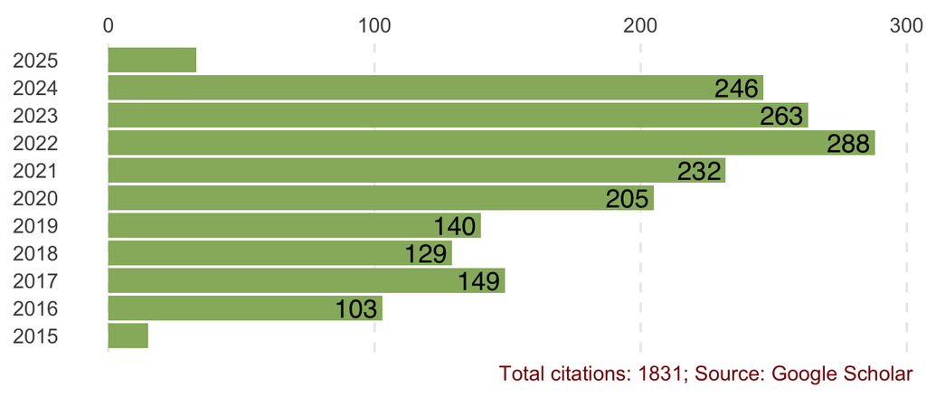

## Talks

| year | number | what |
| --- | --- | --- |
| 2021 | T5 | ESMO Immuno-Oncology Congress 2021[Geneva, Switzerland] 3O - Identification of an endogenous retroviral signature to predict PD-1 blockade response in advanced clear cell renal cell carcinoma: Integra… |
| 2020 | T4 | ESMO ASIA VIRTUAL CONGRESS 2020[Singapore, Republic of Singapore] Development of a flow cytometry-based whole-blood prognostic immune signature in metastatic cancer patients treated with immune checkp… |
|  | T3 | KSMO 2020 VIRTUAL (13th Annual Meeting & 2020 International Conference; The Korean Society of Medical Oncology; 8th International FACO Conference) [SEOUL, KOREA] Identification of nine lncRNAs signatu… |
| 2019 | T2 | ESMO ASIA CONGRESS 2019[Singapore, Republic of Singapore] Olanzapine combined with 5-HT3 RA plus dexamethasone for prevention and treatment of chemotherapy-induced nausea and vomiting in cancer patien… |
|  | T1 | EUROPEAN ASSOCIATION OF NEURO-ONCOLOGY 2019 (14TH Meeting) [ LYON, FRANCE] Development and Validation of a RNA-Seq Based Prognostic Signature in Neuroblastoma |

## Poster presentations

| year | number | what |
| --- | --- | --- |
| 2018 | P3 | ESMO Asia 2018 Congress 372P Identification and validation of a prognostic signature in malignant pleural mesothelioma |
| 2023 | P1 | SITC 2023 189 Systematic evaluation of transcriptomic molecular features in advanced renal clear cell carcinoma treated with immunotherapy |
|  | P2 | SITC 2023 46 Efficacy of atezolizumab and docetaxel in patients with HER2-positive non-small cell lung cancer: a pooled post hoc of the OAK and POPLAR trials |

## Teaching experience

| year | what |
| --- | --- |
| 2022 | International Academic Exchange, basic course for doctoral students, Zunyi Medical University |
| 2022 | Introduction to Clinical Research, Clinical Medicine Nanshan Class, Zunyi Medical University |

# Links

[^1]: https://github.com/OncoHarmony-Network
[^2]: https://www.zy2yy.cn/
[^3]: https://www.zy2yy.cn/
[^4]: https://www.zy2yy.cn/
[^5]: https://www.zy2yy.cn/
[^6]: https://www.fau.de/
[^7]: https://www.strahlenklinik.uk-erlangen.de
[^8]: https://www.zmu.edu.cn/
[^9]: https://www.zy2yy.cn/
[^10]: https://www.zmu.edu.cn/
[^11]: http://www.huilangongyi.org.cn/
[^12]: https://www.nsfc.gov.cn/
[^13]: https://wjw.guizhou.gov.cn/